# Proyecto Final de Business Performance

Rafael Bedolla Guiscafré

26/11/2019

## Definición de expresiones regulares

**“Expresiones regulares ”**

Las expresiones regulares son una secuencia de caracteres que conforma un patrón de búsqueda. También son conocidas como regex o regexp,3 por su contracción de las palabras inglesas regular expression. Son principalmente utilizadas para la búsqueda de patrones de cadenas de caracteres u operaciones de sustituciones.

En esta sección se van a analizar dos distintas páginas que hablen sobre las expresiones regulares.

En la página [Rpubs](http://rpubs.com/ydmarinb/429756) nos habla desde un inicio los puntos básicos y necesarios para entender lo que son las expresiones regulares mencionando que las expresiones regulares se construyen utilizando los operadores unión, concatenación y clausura de kleene(operación que se aplica y representa el conjunto de las cadenas que se pueden formar).Tomando en cuenta los cuantificadores, la alternación, la agrupación, barra invertida, el signo de admiración, meta caracteres especiales; nos da ejemplos de cómo ir implementado en R y al final como reemplazar el patrón. Le doy una buena valoración, aunque falta contenido y una mejor explicación de cómo se utilizan.

Por otro lado en la otra página de [adictos al trabajo web](https://www.adictosaltrabajo.com/2015/01/29/regexsam/) podemos observar a diferencia que la primera, esta tiene una manera básica y simple de entender y de usar las expresiones; dando una breve introducción del uso por lo cual muestra una lista muy completa de elementos básicos para la creación de las expresiones regulares.

### Contenido de las páginas de Expresiones Regulares

**“Contenido ”**

Las dos páginas tienen puntos muy exactos sobre algunos puntos importantes que se deben de considerar para tomar en cuenta en estas páginas son los siguientes:

- Crear una expresión regular
- Comprobar textos
- Caracteres especiales
- Cuantificadores
- Modificadores
- Métodos de Reg Exp
- Métodos de String
- Propiedades de RegExp
- Expresiones regulares habituales

Le doy una buena valoración a las dos páginas, pero comparando la primera [Rpubs](http://rpubs.com/ydmarinb/429756) puedo decir que tiene un gran contenido y buena explicación pero para una persona que tiene mejor entendimiento sobe R ya que resume muchas cosas y explica en un grado elevado para personan con conocimientos; a su vez [adictos al trabajo web](https://www.adictosaltrabajo.com/2015/01/29/regexsam/) es una página básica para que te ayude a entender lo básico y recordarle a las personas que llegaron a entender y a utilizar las expresiones regulares. Es por eso que la primera es mejor para los que tienen un mínimo de conocimiento de las expresiones y la segunda es de gran apoyo para empezar a aprender o retomar lo que alguna vez se vio y se olvido.

## Markdown

**“Markdown ”**

Rmarkdown permite la creación de informes estáticos que combinan texto con código y resultados, gráficos incluídos, generados con R. Aprender Rmarkdown implica aprender dos cosas distintas:

Markdown, un formato para escribir documentos simples en modo texto. Tiene la ventaja de ser fácilmente legible por humanos pero, a la vez, procesable programáticamente para volcarlos en otros formatos: pdf, html, etc.

En [R ejemplo](https://www.earthdatascience.org/courses/earth-analytics/document-your-science/intro-to-the-rmarkdown-format-and-knitr/) podemos observar que es un simple tutorial en que te va llevando paso a paso para crear un archivo y lo representara en HTML, en el que se establecen objetivos de aprendizaje básicos, simples y necesarios para lograr crear informes combinados.

En esta página de [rpubs](http://www.rpubs.com/JohanMarin/Rmarkdown)da un breve resumen sobre el uso del Markdown para poder empezar a crear tu primer archivo, en el cual se tiene un resumen directo sobre qué es y se va directo a la estructura de un documento en HTML.

La comparación de estas dos páginas es mínima ya que las dos son muy concisas sobre la aplicación de un R Markdown, a las doy des doy una gran valoración ya que llevan un buen orden sobre el cómo ir aplicando para poder realizar un documento, la única diferencia que puedo encontrar es que en la primera página te da al final en ejercicio a realizar para que uno pueda practicar y eso siempre es bueno para tener un mejor entendimiento.

## Estudio y representación de los datos

### Estructura de los datos a analizar

**“Estructura de datos ”**

Se van a mostrar diferentes ejemplos de diferentes datos que se analizaron

En el primer ejemplo podemos observar que:

Según https://es.wikipedia.org/wiki/Poblaci%C3%B3n_mundial la población mundial va en aumento y según las estimaciones de la ONU el año 2008, cada minuto nacen entre 323 y 358 bebés en todo el mundo y los países más poblados por continente son y las ciudades más pobladas por continente son:

| Continente | Densidad(hab./km²) | Superficie(km²) | Poblacion_2019 | País más poblado(2019) | Ciudad más poblada(2019) |
| --- | --- | --- | --- | --- | --- |
| Asia | 86,88 | 43.810.000 | 4.677.291.000 | China (1.392.240.000) | Tokio (40.810.000) |
| África | 32,7 | 30.370.000 | 1.110.020.000 | Nigeria (191.205.000) | El Cairo (29.251.000) |
| Europa | 70 | 10.180.000 | 801.000.000 | Rusia (112.000.000 Europa) | Moscú (18.940.000) |
| América | 23,5 | 42.330.000 | 1.094.215.000 | Estados Unidos (330.028.000) | Ciudad de México (27.950.000)[10] |
| Oceanía | 4,25 | 9.008.500 | 40.201.000 | Australia (27.240.000) | Sídney (6.550.000) |
| Antártida | 0,0003(varía) | 13.720.000 | 4.490(no permanente, varía)[11] | N.D.[nota 1] | N.D. |

En este segundo ejemplo se puede observar la imagen de un mapa con la Poblacion mundial poblicada en un [articulo](https://www.lavanguardia.com/economia/20170506/422335535562/el-mundo-crece-en-las-ciudades.html) el cual menciona que el 54,5% de la población mundial ya vive en las ciudades, y llega al 75% en Europa y al 82% en Estados Unidosy la acumulacion respectiva de los paises mas importantes de cada continente.

[figure not shown]

Población

En este tercer ejemplo podemos observar que se hizo un analisis mediante una grafica Estos datos proporcionan aceleraciones máximas medidas en varias estaciones de observación para 23 terremotos en California.

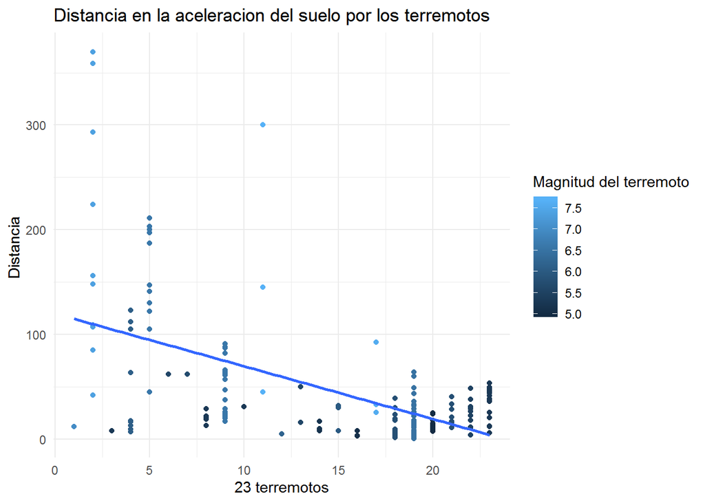

## Conclusión

**“Conclusión ”**

Este proyecto final es un pequeño trabajo en el cual demostramos gracias a la herramienta de R Markdow un poco de lo aprendido en la materia de Business Performance en la cual aprendimos expresiones regulares y comandos para poder programar libremente, manejar bases de datos y poder hacer análisis estadísticos impartida por [Carlos J. Gil Bellosta](https://www.linkedin.com/in/carlos-j-gil-bellosta-9b02291/)